# Getting Started with STAN and CmdStanR

## What is this?

I’ve experimented with STAN via the `ulam()` command from `rethinking`, but have reached the point where this approach is getting too cumbersome and difficult to debug. It’s time to switch to using STAN directly!

## CmdStanR

Stan is distinct from R: you have to write `.stan` files and compile them. But it’s convenient to do this using R as a front-end so we can manipulate data in advance, summarize results, etc. There are two main ways of doing this. The first is [Rstan](https://mc-stan.org/users/interfaces/rstan) and the second is [CmdStanR](https://mc-stan.org/cmdstanr/). Without getting into the [differences](https://mc-stan.org/cmdstanr/articles/cmdstanr.html#comparison-with-rstan) here, it appears that CmdStanR is a better approach on the whole. I’ll begin by working through [Getting started with CmdStanR](https://mc-stan.org/cmdstanr/articles/cmdstanr.html). One thing worth pointing out is that CmdStanR relies on the [R6 package](https://r6.r-lib.org/articles/Introduction.html) for object-oriented programming. At some point I need to read up on this. But for the moment, the key thing to know is that `$` is used to access *values* and *methods* in R6.

### Installation

The `CmdStanR` package isn’t on CRAN, but it can be installed from https://mc-stan.org. I’ve already installed it:

```r
library(cmdstanr)
check_cmdstan_toolchain()
```

```
The C++ toolchain required for CmdStan is setup properly!
```

### Compiling a model

There’s an example program that comes with `CmdStanR` called `bernoulli.stan`. It estimates a Bernoulli probability from an iid sample. We can get the path to this example program as follows:

```r
path_to_example <- file.path(cmdstan_path(), 'examples', 'bernoulli', 'bernoulli.stan')
path_to_example
```

```
[1] "/home/frank/.cmdstan/cmdstan-2.32.2/examples/bernoulli/bernoulli.stan"
```

The next step is to creat a CmdStanModel object from the underlying `.stan` file. There’s no data yet: all we’re going to do is compile the `.stan` file:

```r
example_model <- cmdstan_model(path_to_example)
```

That ran extremely quickly, so either the model is very fast to compile or there’s already a compiled version cached somewhere. I think it must be the latter. We can view the path to the executable file as follows:

```r
example_model$exe_file()
```

```
[1] "/home/frank/.cmdstan/cmdstan-2.32.2/examples/bernoulli/bernoulli"
```

and we can print out the underlying `.stan` code as well:

```r
example_model$print()
```

```
data {
  int<lower=0> N;
  array[N] int<lower=0,upper=1> y;
}
parameters {
  real<lower=0,upper=1> theta;
}
model {
  theta ~ beta(1,1);  // uniform prior on interval 0,1
  y ~ bernoulli(theta);
}
```

So the probabilistic model is as follows:
$$\begin{align*}
Y &\sim \text{Bernoulli}(\theta)\\
\theta &\sim \text{Uniform}(0, 1).
\end{align*}$$
### Fitting the Model

Now we’ll use the compiled STAN model to run Hamiltonian MCMC. But first we need some data. We pass this in as a list where the names of the list elements correspond to the names within the `.stan` file:

```r
example_data <- list(N = 10, y = c(0, 1, 0, 0, 0, 0, 0, 0, 0, 1))
```

Now we’ll run four MCMC chains in parallel, printing out a status update after every 500 iterations. Notice that this runs *extremely quickly* because we’ve compiled the model:

```r
example_fit <- example_model$sample(
  data = example_data,
  seed = 123, # random seed for MCMC
  chains = 4,
  parallel_chains = 4,
  refresh = 500 # print status update after every 500 iterations
)
```

```
Running MCMC with 4 parallel chains...

Chain 1 Iteration:    1 / 2000 [  0%]  (Warmup)
Chain 1 Iteration:  500 / 2000 [ 25%]  (Warmup)
Chain 1 Iteration: 1000 / 2000 [ 50%]  (Warmup)
Chain 1 Iteration: 1001 / 2000 [ 50%]  (Sampling)
Chain 1 Iteration: 1500 / 2000 [ 75%]  (Sampling)
Chain 1 Iteration: 2000 / 2000 [100%]  (Sampling)
Chain 2 Iteration:    1 / 2000 [  0%]  (Warmup)
Chain 2 Iteration:  500 / 2000 [ 25%]  (Warmup)
Chain 2 Iteration: 1000 / 2000 [ 50%]  (Warmup)
Chain 2 Iteration: 1001 / 2000 [ 50%]  (Sampling)
Chain 2 Iteration: 1500 / 2000 [ 75%]  (Sampling)
Chain 2 Iteration: 2000 / 2000 [100%]  (Sampling)
Chain 3 Iteration:    1 / 2000 [  0%]  (Warmup)
Chain 3 Iteration:  500 / 2000 [ 25%]  (Warmup)
Chain 3 Iteration: 1000 / 2000 [ 50%]  (Warmup)
Chain 3 Iteration: 1001 / 2000 [ 50%]  (Sampling)
Chain 3 Iteration: 1500 / 2000 [ 75%]  (Sampling)
Chain 3 Iteration: 2000 / 2000 [100%]  (Sampling)
Chain 4 Iteration:    1 / 2000 [  0%]  (Warmup)
Chain 4 Iteration:  500 / 2000 [ 25%]  (Warmup)
Chain 4 Iteration: 1000 / 2000 [ 50%]  (Warmup)
Chain 4 Iteration: 1001 / 2000 [ 50%]  (Sampling)
Chain 4 Iteration: 1500 / 2000 [ 75%]  (Sampling)
Chain 4 Iteration: 2000 / 2000 [100%]  (Sampling)
Chain 1 finished in 0.0 seconds.
Chain 2 finished in 0.0 seconds.
Chain 3 finished in 0.0 seconds.
Chain 4 finished in 0.0 seconds.

All 4 chains finished successfully.
Mean chain execution time: 0.0 seconds.
Total execution time: 0.2 seconds.
```

### Summarizing the Posterior

The `$summary()` method relies on the function `summarize_draws()` from the [`posterior` package](https://cran.r-project.org/web/packages/posterior/vignettes/posterior.html). Calling this method without any arguments generates output that is analogous to that of the `precis()` command from the `rethinking` package, although for some reason it doesn’t display correctly in the quarto notebook preview, it does display correctly after rendering. If I pass it to `knitr::kable()` it looks better and gives a preview:

```r
example_fit$summary() |> knitr::kable(digits = 2)
```

| variable | mean | median | sd | mad | q5 | q95 | rhat | ess_bulk | ess_tail |
| --- | --- | --- | --- | --- | --- | --- | --- | --- | --- |
| lp__ | -7.26 | -6.99 | 0.70 | 0.33 | -8.76 | -6.75 | 1 | 1951.69 | 2046.29 |
| theta | 0.25 | 0.23 | 0.12 | 0.12 | 0.08 | 0.46 | 1 | 1552.21 | 1620.71 |

The row `lp__` refers to the *log unnormalized posterior density*. For some discussion see pthis post](https://discourse.mc-stan.org/t/basic-question-what-is-lp-in-posterior-samples-of-a-brms-regression/17567) from the STAN forums.

For a more detailed summary that doesn’t rely on the `posterior` package, we can use the `$cmdstand_summary()` method. This prints nicely in the preview:

```r
example_fit$cmdstan_summary()
```

```
Inference for Stan model: bernoulli_model
4 chains: each with iter=(1000,1000,1000,1000); warmup=(0,0,0,0); thin=(1,1,1,1); 4000 iterations saved.

Warmup took (0.0010, 0.0010, 0.0010, 0.0010) seconds, 0.0040 seconds total
Sampling took (0.0030, 0.0040, 0.0040, 0.0030) seconds, 0.014 seconds total

                Mean     MCSE  StdDev     5%   50%   95%  N_Eff  N_Eff/s    R_hat

lp__            -7.3  1.7e-02    0.70   -8.8  -7.0  -6.8   1672  1.2e+05      1.0
accept_stat__   0.92  2.1e-03    0.13   0.66  0.97   1.0   3488  2.5e+05  1.0e+00
stepsize__      0.97  6.2e-02   0.088   0.84   1.0   1.1    2.0  1.4e+02  2.7e+13
treedepth__      1.4  8.4e-03    0.49    1.0   1.0   2.0   3412  2.4e+05  1.0e+00
n_leapfrog__     2.6  3.4e-02     1.3    1.0   3.0   3.0   1488  1.1e+05  1.0e+00
divergent__     0.00      nan    0.00   0.00  0.00  0.00    nan      nan      nan
energy__         7.8  2.5e-02     1.0    6.8   7.5   9.8   1664  1.2e+05  1.0e+00

theta           0.25  3.0e-03    0.12  0.082  0.23  0.46   1618  1.2e+05      1.0

Samples were drawn using hmc with nuts.
For each parameter, N_Eff is a crude measure of effective sample size,
and R_hat is the potential scale reduction factor on split chains (at
convergence, R_hat=1).
```

Apparently the `$summary()` method is fairly flexible compared to `$cmdstan_summary()` in that we can customize the output or extract other quantities of interest. Here are a few examples. Here’s how we can compute the posterior probability that $\theta$ is less than 0.5:

```r
example_fit$summary('theta', prob_less_than_half = \(x) mean(x <= 0.5))
```

```
# A tibble: 1 × 2
  variable prob_less_than_half
  <chr>                  <num>
1 theta                  0.968
```

And here’s how we can augment the default summary statistics with some additional quantiles of the posterior. I’m not exactly sure why we use the function `quantile2()` from the `posterior` package here instead of the base R function. The documentation for `quantile2()` doesn’t explain how it’s different.

```r
example_fit$summary(
  variables = NULL, # summarize all variables
  posterior::default_summary_measures(),
  extra_quantiles = \(x) posterior::quantile2(x, probs = c(0.0275, 0.975))
) |> knitr::kable(digits = 2)
```

| variable | mean | median | sd | mad | q5 | q95 | q2.75 | q97.5 |
| --- | --- | --- | --- | --- | --- | --- | --- | --- |
| lp__ | -7.26 | -6.99 | 0.70 | 0.33 | -8.76 | -6.75 | -9.23 | -6.75 |
| theta | 0.25 | 0.23 | 0.12 | 0.12 | 0.08 | 0.46 | 0.07 | 0.52 |

### Posterior Draws

Extract these using the `$draws()` method from the `posterior` package. Apparently these can be extracted in various different formats, e.g. as an array, a dataframe and so on. Here are two examples. First extract draws as an array:

```r
posterior_draws_array <- example_fit$draws() # defaults to format = 'array'
str(posterior_draws_array)
```

```
 'draws_array' num [1:1000, 1:4, 1:2] -9.66 -7.58 -6.75 -7 -7.49 ...
 - attr(*, "dimnames")=List of 3
  ..$ iteration: chr [1:1000] "1" "2" "3" "4" ...
  ..$ chain    : chr [1:4] "1" "2" "3" "4"
  ..$ variable : chr [1:2] "lp__" "theta"
```

```r
posterior_draws_array
```

```
# A draws_array: 1000 iterations, 4 chains, and 2 variables
, , variable = lp__

         chain
iteration    1    2    3    4
        1 -9.7 -7.1 -7.1 -6.8
        2 -7.6 -6.9 -7.1 -7.0
        3 -6.7 -7.0 -6.8 -7.4
        4 -7.0 -7.1 -6.7 -7.4
        5 -7.5 -7.2 -7.4 -9.4

, , variable = theta

         chain
iteration    1    2    3    4
        1 0.59 0.15 0.15 0.24
        2 0.43 0.33 0.16 0.34
        3 0.25 0.16 0.26 0.40
        4 0.17 0.37 0.26 0.40
        5 0.42 0.15 0.41 0.58

# ... with 995 more iterations
```

Second, extract draws as a dataframe:

```r
posterior_draws_dataframe <- example_fit$draws(format = 'df')
str(posterior_draws_dataframe)
```

```
draws_df [4,000 × 5] (S3: draws_df/draws/tbl_df/tbl/data.frame)
 $ lp__      : num [1:4000] -9.66 -7.58 -6.75 -7 -7.49 ...
 $ theta     : num [1:4000] 0.593 0.429 0.254 0.169 0.418 ...
 $ .chain    : int [1:4000] 1 1 1 1 1 1 1 1 1 1 ...
 $ .iteration: int [1:4000] 1 2 3 4 5 6 7 8 9 10 ...
 $ .draw     : int [1:4000] 1 2 3 4 5 6 7 8 9 10 ...
```

```r
posterior_draws_dataframe
```

```
# A draws_df: 1000 iterations, 4 chains, and 2 variables
   lp__ theta
1  -9.7  0.59
2  -7.6  0.43
3  -6.7  0.25
4  -7.0  0.17
5  -7.5  0.42
6  -9.2  0.56
7  -7.0  0.17
8  -6.8  0.24
9  -7.8  0.46
10 -7.8  0.46
# ... with 3990 more draws
# ... hidden reserved variables {'.chain', '.iteration', '.draw'}
```

There are also functions for converting between one format and another. For example, we can convert from array to dataframe as follows:

```r
posterior_draws_dataframe2 <- posterior::as_draws_df(posterior_draws_array)
identical(posterior_draws_dataframe, posterior_draws_dataframe2)
```

```
[1] TRUE
```

### Plotting the Posterior

There are many ways to do this. Here’s a simple example using the `bayesplot` package

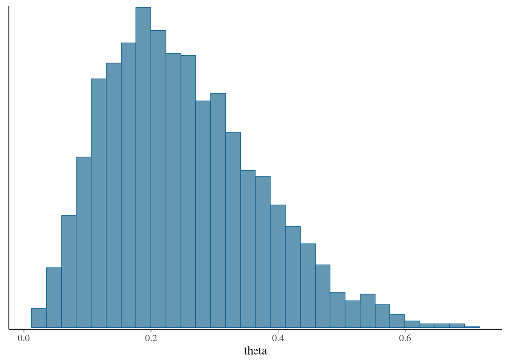

```r
library(bayesplot)
example_fit$draws('theta') |> mcmc_hist()
```

### Diagnostics

This gives a ton of information and I don’t know what all of it means:

```r
example_fit$sampler_diagnostics()
```

```
# A draws_array: 1000 iterations, 4 chains, and 6 variables
, , variable = treedepth__

         chain
iteration 1 2 3 4
        1 1 2 1 1
        2 1 1 2 1
        3 1 1 2 1
        4 2 1 1 1
        5 1 1 1 1

, , variable = divergent__

         chain
iteration 1 2 3 4
        1 0 0 0 0
        2 0 0 0 0
        3 0 0 0 0
        4 0 0 0 0
        5 0 0 0 0

, , variable = energy__

         chain
iteration    1   2   3   4
        1 10.3 7.9 7.4 9.2
        2  9.0 7.9 8.7 7.0
        3  7.4 7.8 7.6 7.4
        4  8.0 8.0 6.8 8.1
        5  8.1 8.5 7.5 9.5

, , variable = accept_stat__

         chain
iteration    1    2    3    4
        1 0.54 0.87 1.00 0.55
        2 1.00 0.93 0.86 0.94
        3 1.00 0.88 0.95 0.86
        4 0.77 0.91 1.00 0.80
        5 0.87 0.78 0.86 0.46

# ... with 995 more iterations, and 2 more variables
```

We can obtain a summary as follows. Here there are no warnings, but if there were some it would print them out:

```r
example_fit$diagnostic_summary()
```

```
$num_divergent
[1] 0 0 0 0

$num_max_treedepth
[1] 0 0 0 0

$ebfmi
[1] 1.043908 1.132605 1.078615 1.317367
```

Another way to obtain diagnostics is by using `$cmdstan_diagnose()`. In this case everything looks good, which is unsurprisingly since it’s a conjugate model and we don’t need MCMC in the first place!

```r
example_fit$cmdstan_diagnose()
```

```
Processing csv files: /tmp/RtmpNCOsnz/bernoulli-202308091510-1-727110.csv, /tmp/RtmpNCOsnz/bernoulli-202308091510-2-727110.csv, /tmp/RtmpNCOsnz/bernoulli-202308091510-3-727110.csv, /tmp/RtmpNCOsnz/bernoulli-202308091510-4-727110.csv

Checking sampler transitions treedepth.
Treedepth satisfactory for all transitions.

Checking sampler transitions for divergences.
No divergent transitions found.

Checking E-BFMI - sampler transitions HMC potential energy.
E-BFMI satisfactory.

Effective sample size satisfactory.

Split R-hat values satisfactory all parameters.

Processing complete, no problems detected.
```

### Saving Your Results

Suppose you’ve compiled your model and fitted it to data. Now you’d like to save the resulting CmdStanR object so you can process it further at another time without re-running everything. The recommended way to do this is by using the `$save_object()` method to create an `.RDS` file. I’m not actually going to run this, but I’ll show the code:

```r
example_fit$save_object(file = 'your-filename-here.RDS')
fit_from_file <- readRDS('your-filename-here.RDS')
```